# USED CAR-Copy2

### Processing for variable columns

The Name column in the recent format might not be especially useful in our analysis. Meanwhile the name includes both the brand name and the model’s name of the vehicle, the column would have to many unique values to be useful in prediction.

Creating a new column as the Car_Brand which tells the brand of the car and Name as the model of the car.

### Observations on Car Model Name

```python
#  Model Names
df["Model"] = df["Name"].apply(lambda x: x.split(" ")[1].lower())
```

```python
# Check the data
df["Model"].value_counts()
```

```
swift          418
city           318
i20            303
innova         203
verna          200
alto           183
grand          183
i10            181
wagon          178
polo           178
xuv500         131
vento          129
amaze          127
new            119
creta          118
fortuner       118
ecosport       117
figo           112
3              109
e-class        108
duster          97
santro          95
a4              90
ertiga          86
5               86
ciaz            83
corolla         83
brio            80
etios           80
eon             79
ritz            78
baleno          75
jazz            70
scorpio         69
xcent           68
rover           67
a6              66
celerio         66
rapid           58
superb          58
```

[output cut: 164 more lines]

```
evalia           1
wr-v             1
xuv300           1
montero          1
platinum         1
countryman       1
370z             1
boxster          1
abarth           1
venture          1
flying           1
beetle           1
fortwo           1
gallardo         1
Name: Model, dtype: int64
```

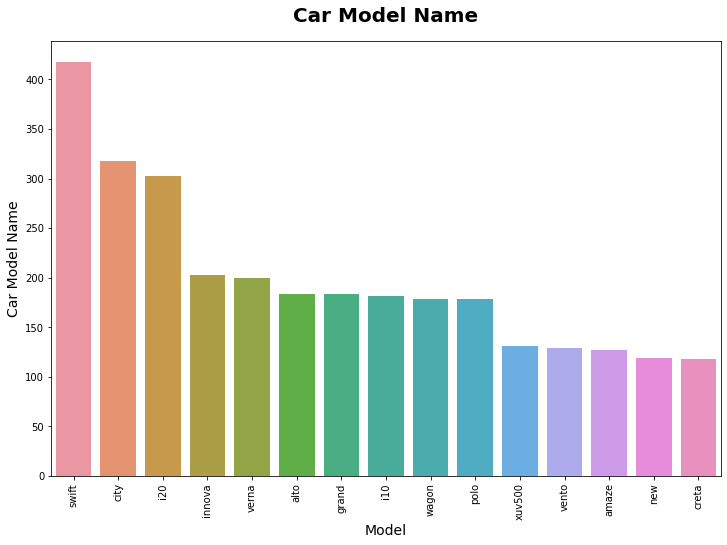

```python
plt.figure(figsize=(12,8))
ax = sns.countplot(x='Model', data=df, order=df['Model'].value_counts().iloc[:15].index)
plt.xticks(rotation='vertical')
plt.xlabel('Model', fontsize=14)
plt.ylabel('Car Model Name', fontsize=14)
plt.title('Car Model Name', fontsize=20, y=1.03, weight='bold')
```

From the graph dataset contains used cars from luxury as well as budget friendly brands.

### Missing value Treatment

```python
# Numeric variables
df.describe().T
```

|  | count | mean | std | min | 25% | 50% | 75% | max |
| --- | --- | --- | --- | --- | --- | --- | --- | --- |
| S.No. | 7253.000 | 3626.000 | 2093.905 | 0.000 | 1813.000 | 3626.000 | 5439.000 | 7252.000 |
| Year | 7253.000 | 2013.365 | 3.254 | 1996.000 | 2011.000 | 2014.000 | 2016.000 | 2019.000 |
| Kilometers_Driven | 7253.000 | 58699.063 | 84427.721 | 171.000 | 34000.000 | 53416.000 | 73000.000 | 6500000.000 |
| Seats | 7253.000 | 5.278 | 0.809 | 0.000 | 5.000 | 5.000 | 5.000 | 10.000 |
| Price | 7253.000 | 8.826 | 10.293 | 0.440 | 3.850 | 5.640 | 8.400 | 160.000 |
| km_per_unit_fuel | 7251.000 | 18.142 | 4.562 | 0.000 | 15.170 | 18.160 | 21.100 | 33.540 |
| engine_number | 7207.000 | 1616.573 | 595.285 | 72.000 | 1198.000 | 1493.000 | 1968.000 | 5998.000 |
| power_number | 7078.000 | 112.765 | 53.494 | 34.200 | 75.000 | 94.000 | 138.100 | 616.000 |
| new_price_num | 1006.000 | 22.780 | 27.759 | 3.910 | 7.885 | 11.570 | 26.043 | 375.000 |

#### Observations

S.No. There are not interpretation then as debated previously we will drop it just letter having looked at the initial linear model. Kilometers Driven values have an extremely high variety. We have to verify some severe values to get a perception of the data. Minimum and maximum number of seats in the car also warrent a quick check. On an normal a car look like to have 5 seats, which is almost right. Used cars have being sold at less than a lakh rupees and as high as 160 lakh, as show for Lamborghini previously. We may have to decline several of these outliers to build a robust model. Min Mileage being 0 is also regarding, we must check about it. Power and Engine median and mean values are not much different. Just someone with more domain information would be capable of comment furthur on these aspects. New price range looks right. There are both budget friendly Maruti cars and Lamborghinis in the stock. Mean being twice that of the median indicates that there are only a few very high range brands, and makes sense

```python
# Checking Kilometers_Driven Extreme values
df.sort_values(by=["Kilometers_Driven"], ascending=True)
```

|  | S.No. | Name | Location | Year | Kilometers_Driven | Fuel_Type | Transmission | Owner_Type | Mileage | Engine | Power | Seats | New_Price | Price | km_per_unit_fuel | mileage_unit | engine_number | power_number | new_price_num | Model |
| --- | --- | --- | --- | --- | --- | --- | --- | --- | --- | --- | --- | --- | --- | --- | --- | --- | --- | --- | --- | --- |
| 1361 | 1361 | Maruti Alto 800 2016-2019 VXI | Mumbai | 2019 | 171 | Petrol | Manual | First | 24.7 kmpl | 796 CC | 47.3 bhp | 5.000 | NaN | 3.600 | 24.700 | kmpl | 796.000 | 47.300 | NaN | alto |
| 5606 | 5606 | Maruti Wagon R ZXI AMT 1.2 | Mumbai | 2019 | 600 | Petrol | Automatic | First | 21.5 kmpl | 1197 CC | 81.80 bhp | 5.000 | 6.8 Lakh | 6.250 | 21.500 | kmpl | 1197.000 | 81.800 | 6.800 | wagon |
| 1198 | 1198 | Volkswagen Polo 1.0 MPI Trendline | Hyderabad | 2019 | 1000 | Petrol | Manual | First | 18.78 kmpl | 999 CC | 75 bhp | 5.000 | 6.74 Lakh | 5.680 | 18.780 | kmpl | 999.000 | 75.000 | 6.740 | polo |
| 5941 | 5941 | Renault KWID RXL | Pune | 2018 | 1000 | Petrol | Manual | First | 25.17 kmpl | 799 CC | 53.3 bhp | 5.000 | 4.45 Lakh | 3.400 | 25.170 | kmpl | 799.000 | 53.300 | 4.450 | kwid |
| 6201 | 6201 | Maruti Alto LXI | Kolkata | 2019 | 1000 | Petrol | Manual | First | 24.7 kmpl | 796 CC | 47.3 bhp | 5.000 | 3.99 Lakh | 5.640 | 24.700 | kmpl | 796.000 | 47.300 | 3.990 | alto |
| ... | ... | ... | ... | ... | ... | ... | ... | ... | ... | ... | ... | ... | ... | ... | ... | ... | ... | ... | ... | ... |
| 2823 | 2823 | Volkswagen Jetta 2013-2015 2.0L TDI Highline AT | Chennai | 2015 | 480000 | Diesel | Automatic | First | 16.96 kmpl | 1968 CC | 138.03 bhp | 5.000 | NaN | 13.000 | 16.960 | kmpl | 1968.000 | 138.030 | NaN | jetta |
| 358 | 358 | Hyundai i10 Magna 1.2 | Chennai | 2009 | 620000 | Petrol | Manual | First | 20.36 kmpl | 1197 CC | 78.9 bhp | 5.000 | NaN | 2.700 | 20.360 | kmpl | 1197.000 | 78.900 | NaN | i10 |
| 1860 | 1860 | Volkswagen Vento Diesel Highline | Chennai | 2013 | 720000 | Diesel | Manual | First | 20.54 kmpl | 1598 CC | 103.6 bhp | 5.000 | NaN | 5.900 | 20.540 | kmpl | 1598.000 | 103.600 | NaN | vento |
| 340 | 340 | Skoda Octavia Ambition Plus 2.0 TDI AT | Kolkata | 2013 | 775000 | Diesel | Automatic | First | 19.3 kmpl | 1968 CC | 141 bhp | 5.000 | NaN | 7.500 | 19.300 | kmpl | 1968.000 | 141.000 | NaN | octavia |
| 2328 | 2328 | BMW X5 xDrive 30d M Sport | Chennai | 2017 | 6500000 | Diesel | Automatic | First | 15.97 kmpl | 2993 CC | 258 bhp | 5.000 | NaN | 65.000 | 15.970 | kmpl | 2993.000 | 258.000 | NaN | x5 |

7253 rows × 20 columns

There is a good possibility that there are outliers. We look at this further as doing the univariate analysis. When looking at the New Price, columns - Year, and Price these entries look feasible.

1000 might be defaulting value in this case. Quite a few cars having driven exactly 1000 km is suspicious.

```python
df["Seats"].value_counts().sort_values(ascending=False)
```

```
5.000     6100
7.000      796
8.000      170
4.000      119
6.000       38
2.000       18
10.000       8
9.000        3
0.000        1
Name: Seats, dtype: int64
```

```python
# Checking seats extreme values
df.sort_values(by=["Seat"], ascending=True).head(5)
```

[output not shown]

```python
# Checking for similar car in our dataset.
df[df["Name"].str.startswith("Audi A4")]
# Audi look like have A4 typically, 5 seats.
```

|  | S.No. | Name | Location | Year | Kilometers_Driven | Fuel_Type | Transmission | Owner_Type | Mileage | Engine | Power | Seats | New_Price | Price | km_per_unit_fuel | mileage_unit | engine_number | power_number | new_price_num | Model |
| --- | --- | --- | --- | --- | --- | --- | --- | --- | --- | --- | --- | --- | --- | --- | --- | --- | --- | --- | --- | --- |
| 4 | 4 | Audi A4 New 2.0 TDI Multitronic | Coimbatore | 2013 | 40670 | Diesel | Automatic | Second | 15.2 kmpl | 1968 CC | 140.8 bhp | 5.000 | NaN | 17.740 | 15.200 | kmpl | 1968.000 | 140.800 | NaN | a4 |
| 50 | 50 | Audi A4 2.0 TDI 177 Bhp Premium Plus | Kochi | 2015 | 13648 | Diesel | Automatic | First | 17.11 kmpl | 1968 CC | 174.33 bhp | 5.000 | NaN | 21.430 | 17.110 | kmpl | 1968.000 | 174.330 | NaN | a4 |
| 65 | 65 | Audi A4 2.0 TDI Multitronic | Jaipur | 2012 | 65664 | Diesel | Automatic | First | 16.55 kmpl | 1968 CC | 140 bhp | 5.000 | NaN | 13.500 | 16.550 | kmpl | 1968.000 | 140.000 | NaN | a4 |
| 103 | 103 | Audi A4 3.0 TDI Quattro Premium | Kolkata | 2010 | 30000 | Diesel | Automatic | First | 14.94 kmpl | 2967 CC | 241.4 bhp | 5.000 | NaN | 9.800 | 14.940 | kmpl | 2967.000 | 241.400 | NaN | a4 |
| 150 | 150 | Audi A4 2.0 TDI 177 Bhp Premium Plus | Coimbatore | 2015 | 48214 | Diesel | Automatic | First | 17.11 kmpl | 1968 CC | 174.33 bhp | 5.000 | NaN | 23.320 | 17.110 | kmpl | 1968.000 | 174.330 | NaN | a4 |
| 717 | 717 | Audi A4 2.0 TDI 177 Bhp Premium Plus | Bangalore | 2013 | 45979 | Diesel | Automatic | Second | 17.11 kmpl | 1968 CC | 174.33 bhp | 5.000 | NaN | 19.500 | 17.110 | kmpl | 1968.000 | 174.330 | NaN | a4 |
| 853 | 853 | Audi A4 2.0 TDI | Delhi | 2011 | 46000 | Diesel | Automatic | Second | 16.55 kmpl | 1968 CC | 147.51 bhp | 5.000 | NaN | 10.990 | 16.550 | kmpl | 1968.000 | 147.510 | NaN | a4 |
| 854 | 854 | Audi A4 2.0 TDI | Kolkata | 2012 | 47346 | Diesel | Automatic | First | 16.55 kmpl | 1968 CC | 147.51 bhp | 5.000 | NaN | 14.500 | 16.550 | kmpl | 1968.000 | 147.510 | NaN | a4 |
| 874 | 874 | Audi A4 2.0 TDI Multitronic | Ahmedabad | 2011 | 59000 | Diesel | Automatic | First | 16.55 kmpl | 1968 CC | 140 bhp | 5.000 | NaN | 12.500 | 16.550 | kmpl | 1968.000 | 140.000 | NaN | a4 |
| 964 | 964 | Audi A4 2.0 TDI | Kolkata | 2009 | 34000 | Diesel | Automatic | First | 16.55 kmpl | 1968 CC | 147.51 bhp | 5.000 | NaN | 9.950 | 16.550 | kmpl | 1968.000 | 147.510 | NaN | a4 |
| 1044 | 1044 | Audi A4 35 TDI Technology | Hyderabad | 2015 | 45000 | Diesel | Automatic | First | 18.25 kmpl | 1968 CC | 187.74 bhp | 5.000 | 55.61 Lakh | 25.000 | 18.250 | kmpl | 1968.000 | 187.740 | 55.610 | a4 |
| 1268 | 1268 | Audi A4 2.0 TDI 177 Bhp Premium Plus | Kochi | 2014 | 77395 | Diesel | Automatic | First | 17.11 kmpl | 1968 CC | 174.33 bhp | 5.000 | NaN | 14.350 | 17.110 | kmpl | 1968.000 | 174.330 | NaN | a4 |
| 1316 | 1316 | Audi A4 2.0 TDI | Delhi | 2013 | 36000 | Diesel | Automatic | Second | 16.55 kmpl | 1968 CC | 147.51 bhp | 5.000 | NaN | 14.000 | 16.550 | kmpl | 1968.000 | 147.510 | NaN | a4 |
| 1637 | 1637 | Audi A4 35 TDI Premium | Coimbatore | 2016 | 68193 | Diesel | Automatic | First | 17.11 kmpl | 1968 CC | 174.33 bhp | 5.000 | NaN | 24.740 | 17.110 | kmpl | 1968.000 | 174.330 | NaN | a4 |
| 1807 | 1807 | Audi A4 2.0 TDI 177 Bhp Premium Plus | Bangalore | 2014 | 21000 | Diesel | Automatic | First | 17.11 kmpl | 1968 CC | 174.33 bhp | 5.000 | NaN | 24.500 | 17.110 | kmpl | 1968.000 | 174.330 | NaN | a4 |
| 1868 | 1868 | Audi A4 New 2.0 TDI Multitronic | Delhi | 2012 | 60000 | Diesel | Automatic | Second | 15.2 kmpl | 1968 CC | 140.8 bhp | 5.000 | NaN | 10.350 | 15.200 | kmpl | 1968.000 | 140.800 | NaN | a4 |
| 1900 | 1900 | Audi A4 3.0 TDI Quattro Premium | Coimbatore | 2012 | 46913 | Diesel | Automatic | First | 14.94 kmpl | 2967 CC | 241.4 bhp | 5.000 | NaN | 16.110 | 14.940 | kmpl | 2967.000 | 241.400 | NaN | a4 |
| 1918 | 1918 | Audi A4 2.0 TDI | Kochi | 2013 | 45330 | Diesel | Automatic | First | 16.55 kmpl | 1968 CC | 147.51 bhp | 5.000 | NaN | 13.190 | 16.550 | kmpl | 1968.000 | 147.510 | NaN | a4 |
| 1929 | 1929 | Audi A4 2.0 TDI 177 Bhp Premium Plus | Chennai | 2014 | 70000 | Diesel | Automatic | First | 17.11 kmpl | 1968 CC | 174.33 bhp | 5.000 | NaN | 18.000 | 17.110 | kmpl | 1968.000 | 174.330 | NaN | a4 |
| 2005 | 2005 | Audi A4 2.0 TDI | Ahmedabad | 2013 | 82002 | Diesel | Automatic | Second | 16.55 kmpl | 1968 CC | 147.51 bhp | 5.000 | NaN | 17.500 | 16.550 | kmpl | 1968.000 | 147.510 | NaN | a4 |
| 2024 | 2024 | Audi A4 New 2.0 TDI Multitronic | Delhi | 2012 | 44555 | Diesel | Automatic | First | 15.2 kmpl | 1968 CC | 140.8 bhp | 5.000 | NaN | 13.500 | 15.200 | kmpl | 1968.000 | 140.800 | NaN | a4 |
| 2044 | 2044 | Audi A4 2.0 TDI | Delhi | 2013 | 67000 | Diesel | Automatic | First | 16.55 kmpl | 1968 CC | 147.51 bhp | 5.000 | NaN | 14.500 | 16.550 | kmpl | 1968.000 | 147.510 | NaN | a4 |
| 2060 | 2060 | Audi A4 2.0 TDI 177 Bhp Technology Edition | Bangalore | 2014 | 24000 | Diesel | Automatic | First | 17.11 kmpl | 1968 CC | 174.33 bhp | 5.000 | NaN | 25.000 | 17.110 | kmpl | 1968.000 | 174.330 | NaN | a4 |
| 2078 | 2078 | Audi A4 2.0 TDI Multitronic | Jaipur | 2011 | 105000 | Diesel | Automatic | Second | 16.55 kmpl | 1968 CC | 140 bhp | 5.000 | NaN | 14.500 | 16.550 | kmpl | 1968.000 | 140.000 | NaN | a4 |
| 2084 | 2084 | Audi A4 2.0 TDI | Mumbai | 2013 | 45200 | Diesel | Automatic | First | 16.55 kmpl | 1968 CC | 147.51 bhp | 5.000 | NaN | 13.500 | 16.550 | kmpl | 1968.000 | 147.510 | NaN | a4 |
| 2114 | 2114 | Audi A4 35 TDI Premium | Hyderabad | 2015 | 50000 | Diesel | Automatic | First | 17.11 kmpl | 1968 CC | 174.33 bhp | 5.000 | NaN | 25.000 | 17.110 | kmpl | 1968.000 | 174.330 | NaN | a4 |
| 2189 | 2189 | Audi A4 2.0 TFSI | Mumbai | 2011 | 38000 | Petrol | Automatic | First | 10.8 kmpl | 1984 CC | 132 bhp | 5.000 | NaN | 12.000 | 10.800 | kmpl | 1984.000 | 132.000 | NaN | a4 |
| 2240 | 2240 | Audi A4 2.0 TDI | Hyderabad | 2014 | 60000 | Diesel | Automatic | First | 16.55 kmpl | 1968 CC | 147.51 bhp | 5.000 | NaN | 24.000 | 16.550 | kmpl | 1968.000 | 147.510 | NaN | a4 |
| 2284 | 2284 | Audi A4 2.0 TDI 177 Bhp Premium Plus | Pune | 2013 | 87000 | Diesel | Automatic | First | 17.11 kmpl | 1968 CC | 174.33 bhp | 5.000 | NaN | 15.500 | 17.110 | kmpl | 1968.000 | 174.330 | NaN | a4 |
| 2298 | 2298 | Audi A4 2.0 TDI | Hyderabad | 2011 | 85000 | Diesel | Automatic | First | 16.55 kmpl | 1968 CC | 147.51 bhp | 5.000 | NaN | 13.950 | 16.550 | kmpl | 1968.000 | 147.510 | NaN | a4 |

[output cut: 60 more lines]

Audi A4 having 0 seats is clearly a data entry error. This column warrents a little outlier care or treat seats == 0 as a missing value. Generally, there is not much to be worried about it.

```python
# Exchange #seats in ro

# Exchange #seats in row index 3999 form 0 to 5

df.loc[3999, "Seats"] = 5.0
```

```python
# Checking seats extreme values
df.sort_values(by=["Seats"], ascending=False).head(5)
```

|  | S.No. | Name | Location | Year | Kilometers_Driven | Fuel_Type | Transmission | Owner_Type | Mileage | Engine | Power | Seats | New_Price | Price | km_per_unit_fuel | mileage_unit | engine_number | power_number | new_price_num | Model |
| --- | --- | --- | --- | --- | --- | --- | --- | --- | --- | --- | --- | --- | --- | --- | --- | --- | --- | --- | --- | --- |
| 2575 | 2575 | Chevrolet Tavera LS B3 10 Seats BSIII | Hyderabad | 2015 | 120000 | Diesel | Manual | First | 14.8 kmpl | 2499 CC | 80 bhp | 10.000 | NaN | 5.500 | 14.800 | kmpl | 2499.000 | 80.000 | NaN | tavera |
| 6242 | 6242 | Tata Sumo EX 10/7 Str BSII | Chennai | 2015 | 196000 | Diesel | Manual | Second | 12.2 kmpl | 1948 CC | 68 bhp | 10.000 | NaN | 5.640 | 12.200 | kmpl | 1948.000 | 68.000 | NaN | sumo |
| 6288 | 6288 | Chevrolet Tavera LS B3 10 Seats BSIII | Hyderabad | 2005 | 150000 | Diesel | Manual | Second | 14.8 kmpl | 2499 CC | 80 bhp | 10.000 | NaN | 5.640 | 14.800 | kmpl | 2499.000 | 80.000 | NaN | tavera |
| 1907 | 1907 | Toyota Qualis FS B3 | Bangalore | 2002 | 63000 | Diesel | Manual | Third | 13.1 kmpl | 2446 CC | 75 bhp | 10.000 | NaN | 3.650 | 13.100 | kmpl | 2446.000 | 75.000 | NaN | qualis |
| 917 | 917 | Tata Sumo DX | Mumbai | 2013 | 20000 | Diesel | Manual | First | 14.07 kmpl | 1978 CC | 83.1 bhp | 10.000 | NaN | 5.250 | 14.070 | kmpl | 1978.000 | 83.100 | NaN | sumo |

Of course, a Toyota Qualis has 10 seats and so does a Tata Sumo. We don't see any data entry error here.

```python
# Checking Mileage - km_per_unit_fuel extreme values
df.sort_values(by=["km_per_unit_fuel"], ascending=True).head()
```

|  | S.No. | Name | Location | Year | Kilometers_Driven | Fuel_Type | Transmission | Owner_Type | Mileage | Engine | Power | Seats | New_Price | Price | km_per_unit_fuel | mileage_unit | engine_number | power_number | new_price_num | Model |
| --- | --- | --- | --- | --- | --- | --- | --- | --- | --- | --- | --- | --- | --- | --- | --- | --- | --- | --- | --- | --- |
| 2597 | 2597 | Hyundai Santro Xing XP | Pune | 2007 | 70000 | Petrol | Manual | First | 0.0 kmpl | 1086 CC | null bhp | 5.000 | NaN | 1.120 | 0.000 | kmpl | 1086.000 | NaN | NaN | santro |
| 2343 | 2343 | Hyundai Santro AT | Hyderabad | 2006 | 74483 | Petrol | Automatic | First | 0.0 kmpl | 999 CC | null bhp | 5.000 | NaN | 2.300 | 0.000 | kmpl | 999.000 | NaN | NaN | santro |
| 5270 | 5270 | Honda City 1.5 GXI | Bangalore | 2002 | 53000 | Petrol | Manual | Second | 0.0 kmpl | NaN | NaN | 5.000 | NaN | 1.850 | 0.000 | kmpl | NaN | NaN | NaN | city |
| 424 | 424 | Volkswagen Jetta 2007-2011 1.9 L TDI | Hyderabad | 2010 | 42021 | Diesel | Manual | First | 0.0 kmpl | 1968 CC | null bhp | 5.000 | NaN | 5.450 | 0.000 | kmpl | 1968.000 | NaN | NaN | jetta |
| 6857 | 6857 | Land Rover Freelander 2 TD4 SE | Mumbai | 2011 | 87000 | Diesel | Automatic | First | 0.0 kmpl | 2179 CC | 115 bhp | 5.000 | NaN | 5.640 | 0.000 | kmpl | 2179.000 | 115.000 | NaN | rover |

We should treat Mileage = 0 as missing values

```python
# Checking Mileage - km_per_unit_fuel extreme values
df.sort_values(by=["km_per_unit_fuel"], ascending=False).head(10)
```

|  | S.No. | Name | Location | Year | Kilometers_Driven | Fuel_Type | Transmission | Owner_Type | Mileage | Engine | Power | Seats | New_Price | Price | km_per_unit_fuel | mileage_unit | engine_number | power_number | new_price_num | Model |
| --- | --- | --- | --- | --- | --- | --- | --- | --- | --- | --- | --- | --- | --- | --- | --- | --- | --- | --- | --- | --- |
| 1332 | 1332 | Maruti Wagon R CNG LXI | Pune | 2013 | 79494 | CNG | Manual | First | 33.54 km/kg | 998 CC | 67.04 bhp | 5.000 | 5.54 Lakh | 2.960 | 33.540 | km/kg | 998.000 | 67.040 | 5.540 | wagon |
| 2059 | 2059 | Maruti Wagon R CNG LXI | Mumbai | 2013 | 54000 | CNG | Manual | First | 33.54 km/kg | 998 CC | 67.04 bhp | 5.000 | 5.58 Lakh | 3.050 | 33.540 | km/kg | 998.000 | 67.040 | 5.580 | wagon |
| 2371 | 2371 | Maruti Wagon R CNG LXI | Pune | 2014 | 29202 | CNG | Manual | First | 33.54 km/kg | 998 CC | 67.04 bhp | 5.000 | 5.54 Lakh | 3.900 | 33.540 | km/kg | 998.000 | 67.040 | 5.540 | wagon |
| 3129 | 3129 | Maruti Wagon R CNG LXI | Delhi | 2014 | 74663 | CNG | Manual | First | 33.54 km/kg | 998 CC | 67.04 bhp | 5.000 | 5.35 Lakh | 3.250 | 33.540 | km/kg | 998.000 | 67.040 | 5.350 | wagon |
| 4141 | 4141 | Maruti Wagon R CNG LXI | Mumbai | 2014 | 47200 | CNG | Manual | First | 33.54 km/kg | 998 CC | 67.04 bhp | 5.000 | 5.58 Lakh | 2.850 | 33.540 | km/kg | 998.000 | 67.040 | 5.580 | wagon |
| 3869 | 3869 | Maruti Alto 800 2016-2019 CNG LXI | Delhi | 2012 | 65537 | CNG | Manual | Second | 33.44 km/kg | 796 CC | 40.3 bhp | 4.000 | NaN | 2.100 | 33.440 | km/kg | 796.000 | 40.300 | NaN | alto |
| 1269 | 1269 | Maruti Alto 800 2016-2019 CNG LXI | Mumbai | 2018 | 10600 | CNG | Manual | First | 33.44 km/kg | 796 CC | 40.3 bhp | 4.000 | NaN | 3.500 | 33.440 | km/kg | 796.000 | 40.300 | NaN | alto |
| 3553 | 3553 | Maruti Alto 800 2016-2019 CNG LXI | Pune | 2015 | 18000 | CNG | Manual | First | 33.44 km/kg | 796 CC | 40.3 bhp | 4.000 | NaN | 3.000 | 33.440 | km/kg | 796.000 | 40.300 | NaN | alto |
| 4769 | 4769 | Maruti Alto 800 2016-2019 CNG LXI | Kochi | 2017 | 24310 | CNG | Manual | First | 33.44 km/kg | 796 CC | 40.3 bhp | 4.000 | NaN | 3.700 | 33.440 | km/kg | 796.000 | 40.300 | NaN | alto |
| 6019 | 6019 | Maruti Alto K10 LXI CNG | Delhi | 2014 | 40929 | CNG | Manual | First | 32.26 km/kg | 998 CC | 58.2 bhp | 4.000 | NaN | 5.640 | 32.260 | km/kg | 998.000 | 58.200 | NaN | alto |

Maruti Alto CNG and Maruti Wagon R varieties are budget friendly cars with high mileage therefore these data points are fine..

```python
# Checking the value counts for non-numeric features

number_to_display = 10  # outlining this up here to change later
for colname in df.dtypes[df.dtypes == "object"].index:
    val_counts = df[colname].value_counts(dropna=False)  # Show the NA counts
    print(val_counts[:number_to_display])
    if len(val_counts) > number_to_display:
        print(f"Only displaying first {number_to_display} of {len(val_counts)} values.")
    print("\n\n")  # for more space in between
```

```
Mahindra XUV500 W8 2WD        55
Maruti Swift VDI              49
Maruti Swift Dzire VDI        42
Honda City 1.5 S MT           39
Maruti Swift VDI BSIV         37
Maruti Ritz VDi               35
Toyota Fortuner 3.0 Diesel    35
Hyundai Grand i10 Sportz      32
Honda Amaze S i-Dtech         32
Honda City 1.5 V MT           32
Name: Name, dtype: int64
Only displaying first 10 of 2041 values.



Mumbai        949
Hyderabad     876
Coimbatore    772
Kochi         772
Pune          765
Delhi         660
Kolkata       654
Chennai       591
Jaipur        499
Bangalore     440
Name: Location, dtype: int64
Only displaying first 10 of 11 values.



Diesel      3852
Petrol      3325
CNG           62
LPG           12
Electric       2
Name: Fuel_Type, dtype: int64



Manual       5204
```

[output cut: 77 more lines]

```



swift     418
city      318
i20       303
innova    203
verna     200
alto      183
grand     183
i10       181
wagon     178
polo      178
Name: Model, dtype: int64
Only displaying first 10 of 218 values.
```

Since we haven't dropped the original columns that we processed, we have a few redunadant output here.

We had checked cars of different Fuel_Type earlier, but we did not encounter the 2 electric cars. Let us check why.

```python
df.loc[df["Fuel_Type"] == "Electric"]
```

|  | S.No. | Name | Location | Year | Kilometers_Driven | Fuel_Type | Transmission | Owner_Type | Mileage | Engine | Power | Seats | New_Price | Price | km_per_unit_fuel | mileage_unit | engine_number | power_number | new_price_num | Model |
| --- | --- | --- | --- | --- | --- | --- | --- | --- | --- | --- | --- | --- | --- | --- | --- | --- | --- | --- | --- | --- |
| 4446 | 4446 | Mahindra E Verito D4 | Chennai | 2016 | 50000 | Electric | Automatic | First | NaN | 72 CC | 41 bhp | 5.000 | 13.58 Lakh | 13.000 | NaN | NaN | 72.000 | 41.000 | 13.580 | e |
| 4904 | 4904 | Toyota Prius 2009-2016 Z4 | Mumbai | 2011 | 44000 | Electric | Automatic | First | NaN | 1798 CC | 73 bhp | 5.000 | NaN | 12.750 | NaN | NaN | 1798.000 | 73.000 | NaN | prius |

Electric cars are new in the marketplace and rare in the dataset. We could think about dropping these two observations if they are turning out to be outliers later. There is a good possibility that we will not be able to create a good price prediction model for electric cars, with the presently available data.

New Price for 6247 entries is missing. We should investigate if we can impute these, or we have to drop this column altogether.

### Missing Value Treatment

Beforehand we look at the separate divisions and contacts, so check the missing value in the data.

```python
df.isnull().sum()
```

```
S.No.                   0
Name                    0
Location                0
Year                    0
Kilometers_Driven       0
Fuel_Type               0
Transmission            0
Owner_Type              0
Mileage                 2
Engine                 46
Power                  46
Seats                   0
New_Price            6247
Price                   0
km_per_unit_fuel        2
mileage_unit            2
engine_number          46
power_number          175
new_price_num        6247
Model                   0
dtype: int64
```

Engine dislocation info of 46 observations is missing and maximum power of 175 entries is missing.

New Price as we know earlier has a huge missing count. We need to see if there is a pattern here.

```python
# Let's drop the redundant columns.
df.drop(columns=["Mileage", "mileage_unit", "Engine", "Power", "New_Price"], inplace=True)
```

```python
# Looking a few rows where #seats is missing
df[df["Seats"].isnull()]
```

|  | S.No. | Name | Location | Year | Kilometers_Driven | Fuel_Type | Transmission | Owner_Type | Seats | Price | km_per_unit_fuel | engine_number | power_number | new_price_num | Model |
| --- | --- | --- | --- | --- | --- | --- | --- | --- | --- | --- | --- | --- | --- | --- | --- |

```python
# Impute missing Seats
df["Seats"] = df.groupby(["Model"])["Seats"].transform(lambda x: x.fillna(x.median()))
```

```python
# Check 'Seats'
df[df["Seats"].isnull()]
```

|  | S.No. | Name | Location | Year | Kilometers_Driven | Fuel_Type | Transmission | Owner_Type | Seats | Price | km_per_unit_fuel | engine_number | power_number | new_price_num | Model |
| --- | --- | --- | --- | --- | --- | --- | --- | --- | --- | --- | --- | --- | --- | --- | --- |

```python
# Maruti Estilo can accomodate 5
df["Seats"] = df["Seats"].fillna(5.0)
```

```python
df.isnull().sum()
```

[output not shown]

```python
#  NAs in power and new_price_num.
# Some car do not contain the new price information at all.
# Estimate the new price using the other features.
# KNN imputation is methods that we could used for this.
# sklearn method requires, if we use them for imputation encode categorical variables.
# So we only will select numeric features for imputation

from sklearn.impute import KNNImputer

imputer = KNNImputer(n_neighbors=3, weights="uniform")  # 3 Nearest Neighbours
temp_df_for_imputation = df[["engine_number", "power_number", "Year", "km_per_unit_fuel", "Seats"]]
temp_df_for_imputation = imputer.fit_transform(temp_df_for_imputation)
temp_df_for_imputation = pd.DataFrame(temp_df_for_imputation,
                                      columns = ["engine_number", "power_number", "Year", "km_per_unit_fuel", "Seats"],
)

# Adding imputed columns to the original dataset
df["power_number"] = temp_df_for_imputation["power_number"]
df["km_per_unit_fuel"] = temp_df_for_imputation["km_per_unit_fuel"]
```

```python
df.isnull().sum()
```

[output not shown]

```python
# Droping the redundant columns.
df.drop(columns=["Name", "S.No."], inplace=True)
# Droping the rows where 'Price' == NaN and proceed to modelling
df = df[df["Price"].notna()]
```

```python
print(f'There are {df.shape[0]} rows and {df.shape[1]} columns after dropping NAN from the target variable')
```

[output not shown]

```python
df['Location'].value_counts()
```

```
Mumbai        949
Hyderabad     876
Coimbatore    772
Kochi         772
Pune          765
Delhi         660
Kolkata       654
Chennai       591
Jaipur        499
Bangalore     440
Ahmedabad     275
Name: Location, dtype: int64
```

Use feature the Location column. Because the location in the data set is of India, we could further grouping the states concurring to their region. For Example, Estern and Northern,Eastern.

```python
#Grouping the states concurring to their region in India
Nothern = ['Delhi','Jaipur']

Western =['Mumbai', 'Pune','Ahmedabad' ]

Eastern = ['Kolkata' ]

Southern = ['Hyderabad', 'Kochi', 'Coimbatore', 'Chennai', 'Banglore']
```

```python
### Defining a user function for continents
def Regions(x):
    if x in Nothern:
        return 'North_India'
    elif x in Western:
        return 'West_India'
    elif x in Eastern:
        return 'East_India'
    else:
        return 'South_India'
```

```python
df['Region'] = df['Location'].apply(Regions)
```

```python
# Checking at unique regions
df['Region'].unique()
```

```
array(['West_India', 'South_India', 'North_India', 'East_India'],
      dtype=object)
```

### Descriptive Statistics

```python
pd.set_option('display.float_format', lambda x: '%.3f' % x)
np.random.seed(1)
df.sample(n=10)
```

|  | Location | Year | Kilometers_Driven | Fuel_Type | Transmission | Owner_Type | Seats | Price | km_per_unit_fuel | engine_number | power_number | new_price_num | Model | Region |
| --- | --- | --- | --- | --- | --- | --- | --- | --- | --- | --- | --- | --- | --- | --- |
| 2397 | Kolkata | 2016 | 21460 | Petrol | Manual | First | 5.000 | 6.000 | 17.000 | 1497.000 | 121.360 | 9.470 | ecosport | East_India |
| 3777 | Kochi | 2015 | 49818 | Petrol | Manual | First | 5.000 | 4.110 | 21.500 | 1197.000 | 81.800 | 5.440 | wagon | South_India |
| 4425 | Hyderabad | 2007 | 130000 | Diesel | Manual | First | 7.000 | 6.000 | 13.100 | 2499.000 | 141.000 | NaN | endeavour | South_India |
| 3661 | Coimbatore | 2016 | 39753 | Diesel | Automatic | First | 5.000 | 35.280 | 13.000 | 2143.000 | 201.100 | NaN | e-class | South_India |
| 4514 | Kochi | 2016 | 45560 | Petrol | Automatic | First | 5.000 | 6.340 | 16.900 | 1197.000 | 82.000 | NaN | xcent | South_India |
| 599 | Coimbatore | 2019 | 40674 | Diesel | Automatic | First | 7.000 | 24.820 | 11.360 | 2755.000 | 171.500 | 28.050 | innova | South_India |
| 186 | Bangalore | 2014 | 37382 | Diesel | Automatic | First | 5.000 | 32.000 | 13.000 | 2143.000 | 201.100 | NaN | e-class | South_India |
| 305 | Kochi | 2014 | 61726 | Diesel | Automatic | First | 5.000 | 20.770 | 17.680 | 1968.000 | 174.330 | NaN | a6 | South_India |
| 4582 | Kolkata | 2011 | 36000 | Petrol | Manual | First | 5.000 | 2.500 | 18.500 | 1197.000 | 80.000 | NaN | i20 | East_India |
| 5434 | Kochi | 2019 | 13913 | Petrol | Manual | First | 5.000 | 8.200 | 17.500 | 1199.000 | 88.700 | 9.360 | wr-v | South_India |

```python
#Graphic statistics for Numerical columns
pd.set_option('display.float_format', lambda x: '%.3f' % x)
df.describe().T
```

|  | count | mean | std | min | 25% | 50% | 75% | max |
| --- | --- | --- | --- | --- | --- | --- | --- | --- |
| Year | 7253.000 | 2013.365 | 3.254 | 1996.000 | 2011.000 | 2014.000 | 2016.000 | 2019.000 |
| Kilometers_Driven | 7253.000 | 58699.063 | 84427.721 | 171.000 | 34000.000 | 53416.000 | 73000.000 | 6500000.000 |
| Seats | 7253.000 | 5.278 | 0.807 | 2.000 | 5.000 | 5.000 | 5.000 | 10.000 |
| Price | 7253.000 | 8.826 | 10.293 | 0.440 | 3.850 | 5.640 | 8.400 | 160.000 |
| km_per_unit_fuel | 7253.000 | 18.140 | 4.563 | 0.000 | 15.170 | 18.160 | 21.100 | 33.540 |
| engine_number | 7207.000 | 1616.573 | 595.285 | 72.000 | 1198.000 | 1493.000 | 1968.000 | 5998.000 |
| power_number | 7253.000 | 112.176 | 53.339 | 34.200 | 74.000 | 93.700 | 138.030 | 616.000 |
| new_price_num | 1006.000 | 22.780 | 27.759 | 3.910 | 7.885 | 11.570 | 26.043 | 375.000 |

#### Observations

There is big difference seen among the minimum and the maximum value for power which may a sign of extreme values or outliers.

50% of the cars in the data set are of 2014 edition.

There are regular cars in the data set is a 5 seater car.

```python
 # Graphic statistics for Categorical columns
df.describe(exclude = np.number).T
```

|  | count | unique | top | freq |
| --- | --- | --- | --- | --- |
| Location | 7253 | 11 | Mumbai | 949 |
| Fuel_Type | 7253 | 5 | Diesel | 3852 |
| Transmission | 7253 | 2 | Manual | 5204 |
| Owner_Type | 7253 | 4 | First | 5952 |
| Model | 7253 | 218 | swift | 418 |
| Region | 7253 | 4 | South_India | 3451 |

#### Observations

Mumbai is the city has most car been sold or available.

There are 5 kind fuel type and which diesel has most frequency.

There are 2 kind transmission and manuals have the maximum frequency.

There are 4 kind of owner type and firsthand cars has the maximum frequency.

There are 4 different regions and south India has maximum sale and purchase.

## Problem definition, questions to be answered - Data background and contents - Univariate analysis - Bivariate analysis

## Univariate analysis

### Observations on Owner Type

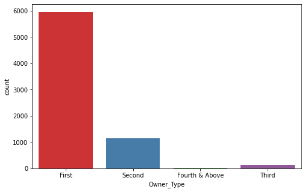

```python
plt.figure(figsize=(8,5))
sns.countplot(df['Owner_Type'], palette="Set1")
plt.show();
```

#### Observations

There are maximum first hand cars owners in the data set and only some third hand owners and beyond a considerable drop can be seen among first hand, second hand owners and third hand owners.

### Observations on Fuel Type

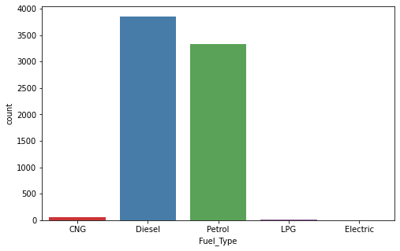

```python
plt.figure(figsize=(8,5))
sns.countplot(df['Fuel_Type'], palette="Set1")
plt.show();
```

#### Observations

There are Petrol cars, Diesel cars, some CNG and litle LPG cars.

### Observations on Transmission

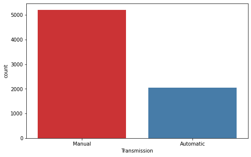

```python
plt.figure(figsize=(8,5))
sns.countplot(df['Transmission'], palette="Set1")
plt.show();
```

#### Observations

Manual cars are maximum

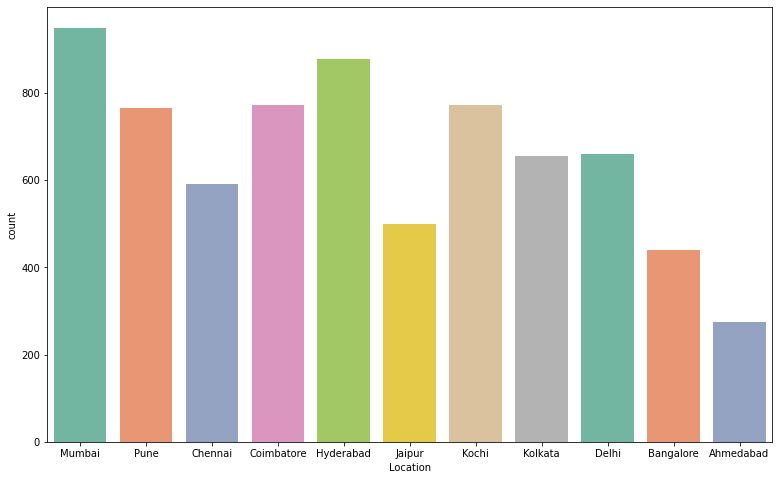

```python
#How many males and females in graphic
plt.figure(figsize=(13,8))
sns.countplot(df['Location'], palette="Set2")
plt.show();
```

```python
plt.figure(figsize=(5,5))
ax = sns.countplot(df['brand'],palette='winter')
```

[output not shown]

### Check Plot Histogram for all Numerical columns

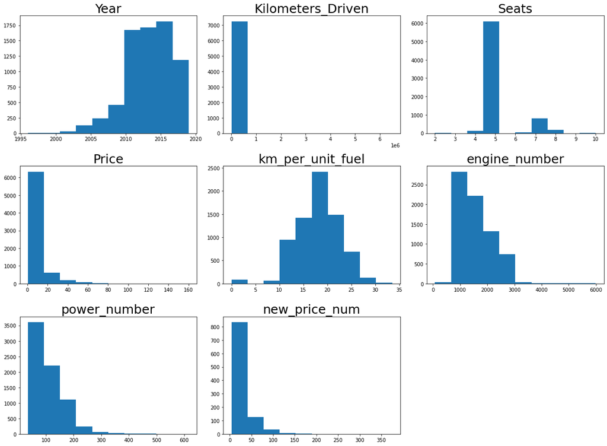

```python
# Plot histogram of all
from scipy.stats import norm
all_col = df.select_dtypes(include=np.number).columns.tolist()
plt.figure(figsize=(17,75))

for i in range(len(all_col)):
    plt.subplot(18,3,i+1)
    plt.hist(df[all_col[i]])
    #sns.histplot(df[all_col[i]], kde=True)   #we can get distribution curves too by this one.
    plt.tight_layout()
    plt.title(all_col[i],fontsize=25)
```

### Check Outliers in Every Numerical Columns

[figure not shown]

```python
plt.figure(figsize=(20,10))
df= sns.load_dataset("titanic")
numeric_variables = list(df.select_dtypes('int64').columns)
for i, c in enumerate(numeric_variables, 1):
    plt.subplot(2,2,i)
    g = sns.boxplot(x=c, y="fare",data=df)
```

## Bivariate analysis

#### Check The Correlations

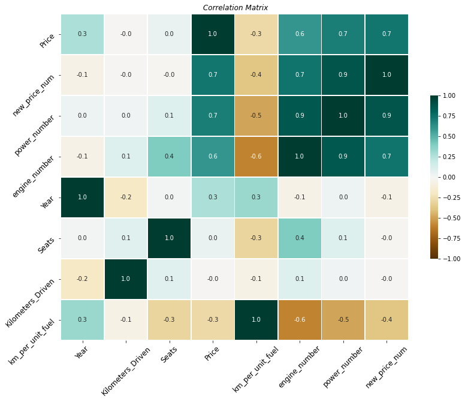

```python
numeric_columns = df.select_dtypes(include = np.number).columns.tolist()

# separating correlations w.r.t Price
corr = df[numeric_columns].corr().sort_values(by = ['Price'], ascending = False)

# matplotlib figure
f, ax = plt.subplots(figsize = (13, 10))


# heatmap with the mask and correct aspect ratio
sns.heatmap(corr, cmap = 'BrBG', annot = True, fmt = ".1f", vmin = -1, vmax = 1, center = 0, square = False,
            linewidths = .7, cbar_kws = {"shrink": .5});
plt.title(' Correlation Matrix', fontstyle = 'italic')
plt.tick_params(axis='both', labelsize = 12, labelrotation = 45)
plt.show()
```

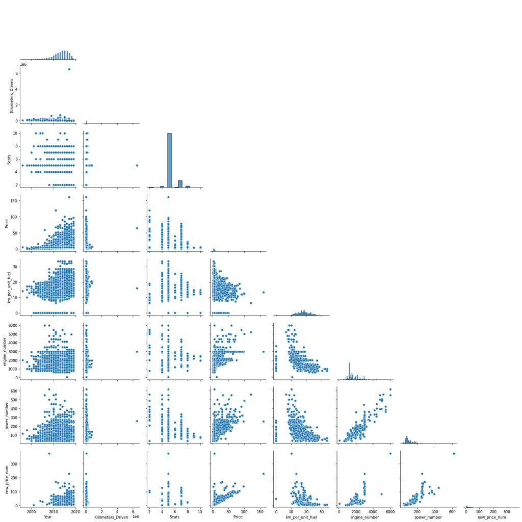

```python
sns.pairplot(df, corner = True );
```

Other negatively correlated variables are: Mileage with Engine (-0.6), and Mileage with Power(-0.5) . The correlation among Engine, and Power. Mileage and Engine and Mileage and Power and shows a great multicollinearity.

### Price vs Engine vs Categorical Variables( with hue as Fuel_Type, Owner_Type and Transmission

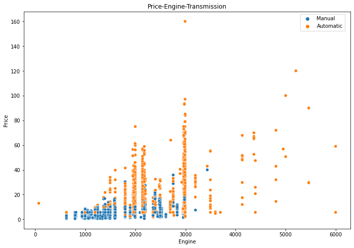

```python
grid = plt.GridSpec(3, 2, wspace=0.6, hspace=0.4) #Defining the grid space
#Checking Price-Engine-Transmission
plt.figure(figsize=[30,30])
ax0 = plt.subplot(grid[0, 0])
sns.scatterplot(y= 'Price', x ='engine_number', hue = 'Transmission', data = df)
ax0.set_ylabel('Price')
ax0.set_xlabel('Engine')
plt.title('Price-Engine-Transmission')
plt.legend(bbox_to_anchor=(0.99,1));
```

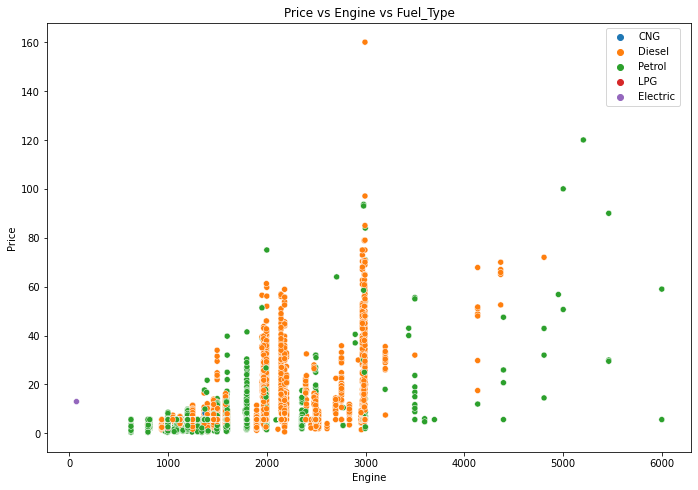

```python
grid = plt.GridSpec(3, 2, wspace=0.6, hspace=0.4) #Identifying the grid space
#Checking Price-Engine-Fuel_Type
plt.figure(figsize=[30,30])
ax1 = plt.subplot(grid[0, 1])
sns.scatterplot(y= 'Price', x = 'engine_number', hue = 'Fuel_Type', data = df)
ax1.set_ylabel('Price')
ax1.set_xlabel('Engine')
plt.title('Price vs Engine vs Fuel_Type' )
plt.legend(bbox_to_anchor=(0.99,1));
```

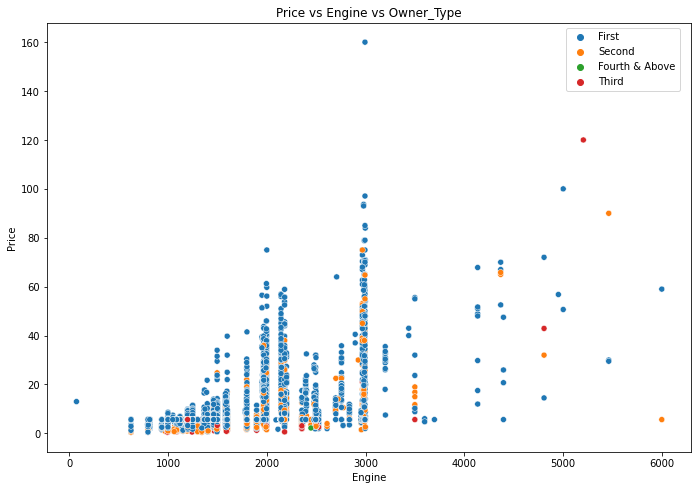

```python
grid = plt.GridSpec(3, 2, wspace=0.6, hspace=0.4) #Defining the grid space
#Check  Price-Engine-Owner_Type
plt.figure(figsize=[30,30])
ax2 = plt.subplot(grid[1, 0])
sns.scatterplot(y= 'Price', x = 'engine_number', hue = 'Owner_Type', data = df)
ax2.set_ylabel('Price')
ax2.set_xlabel('Engine')
plt.title('Price vs Engine vs Owner_Type')
plt.legend(bbox_to_anchor=(0.99,1));
```

```python
grid = plt.GridSpec(3, 2, wspace=0.6, hspace=0.4) #Defining the grid space
# Checking Price-Engine-location
plt.figure(figsize=[30,30])
ax3 = plt.subplot(grid[1, 1])
sns.scatterplot(y= 'Price', x = 'engine_num', hue = 'region', data = df)
ax3.set_ylabel('Price')
ax3.set_xlabel('Engine')
plt.title('Price vs Engine vs region')
plt.legend(bbox_to_anchor=(0.99,1));
```

[output not shown]

Automatic cars offer extra power than manual cars and are extra costly in contrast with the manual cars.

Diesel cars are more expensive with power less than 300 and more other number of expensive Petrol cars with power bigger than 300.

```python
print(df[(df['Owner_Type'] == 'Third') & (df['power_number'] > 500)])
print('-'*90)
print(df[(df['Region'] == 'North_India') & (df['power_number']> 500)])
```

```
     Location  Year  Kilometers_Driven Fuel_Type Transmission Owner_Type  \
5781    Delhi  2011               6500    Petrol    Automatic      Third

      Seats   Price  km_per_unit_fuel  engine_number  power_number  \
5781  2.000 120.000             6.400       5204.000       560.000

      new_price_num     Model       Region
5781            NaN  gallardo  North_India
------------------------------------------------------------------------------------------
     Location  Year  Kilometers_Driven Fuel_Type Transmission Owner_Type  \
5781    Delhi  2011               6500    Petrol    Automatic      Third

      Seats   Price  km_per_unit_fuel  engine_number  power_number  \
5781  2.000 120.000             6.400       5204.000       560.000

      new_price_num     Model       Region
5781            NaN  gallardo  North_India
```

### Price - New Price

```python
plt.figure(figsize = (10,8))
sns.scatterplot(y = 'Price', x = 'new_price',data = df);
```

[output not shown]

#### Plotting categorical variables with Price

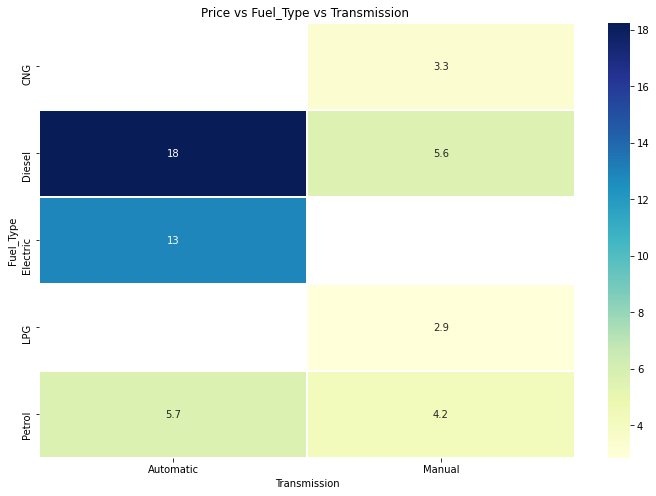

```python
df_hm =df.pivot_table(index = 'Fuel_Type', columns = 'Transmission', values = "Price", aggfunc = np.median)
# Heatmap
f, ax = plt.subplots(figsize = (12, 8))
sns.heatmap(df_hm, cmap = 'YlGnBu', linewidths = .5, annot = True, ax = ax);
plt.title('Price vs Fuel_Type vs Transmission ');
```

Automated used diesel cars have a greater price in contrast with the others

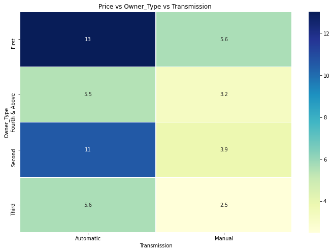

```python
df_hm =df.pivot_table(index = 'Owner_Type', columns = 'Transmission', values = "Price", aggfunc = np.median)
# Heatmap
f, ax = plt.subplots(figsize = (12, 8))
sns.heatmap(df_hm, cmap = 'YlGnBu', linewidths = .5, annot = True, ax = ax);
plt.title('Price vs Owner_Type vs Transmission ');
```

Automatic First hand cars have a greater price in comparison than others

[figure not shown]

```python
# df_hm =data.pivot_table(index = 'Region', columns = 'Fuel_Type', values = "Price", aggfunc = np.median)
# Heatmap
f, ax = plt.subplots(figsize = (12, 8))
sns.heatmap(df_hm, cmap = 'coolwarm', linewidths = .5, annot = True, ax = ax);
plt.title('Price vs Fuel_Type vs Region ');
```

#### Price change with the year of editon

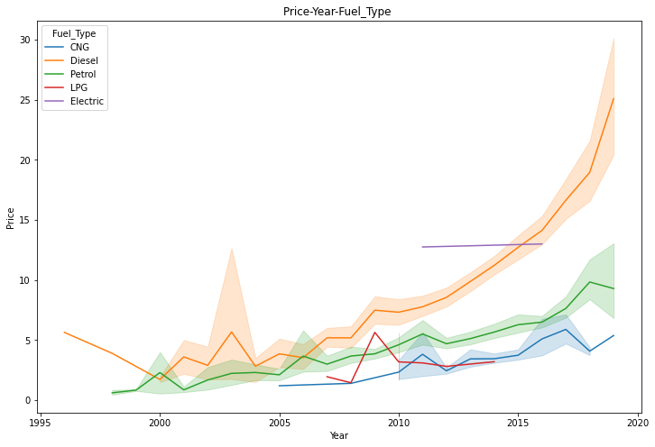

```python
#Price,.. Year,.. Fuel Type
plt.figure(figsize = (12,8))
sns.lineplot(x = 'Year', y = 'Price', hue = 'Fuel_Type', ci = 95, data = df);
plt.title('Price-Year-Fuel_Type ');
```

Petrol and Diesel used cars price show a continual increase. But, Diesel cars are more expensive than Petrol cars.

CNG cars have been out ever since 2005 and LPG cars since 2007. There are not a lot change seen in price increase.

The price for electric cars is constant across the years.

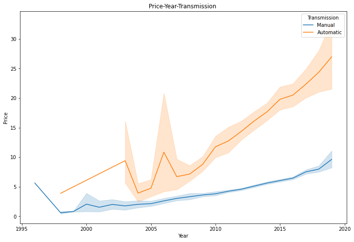

```python
#Price, Year,and Transmission
plt.figure(figsize = (12,8))
sns.lineplot(x = 'Year', y = 'Price', hue = 'Transmission', ci = 95, data = df);
plt.title('Price-Year-Transmission ');
```

Manual cars price has shown a smooth incline over the time.

Automatic cars price was not increase steady across the years. 2 main drops can be seen, one in 2007 and the other in 2004. From 2008, Automatic cars price can be showing a steep incline.

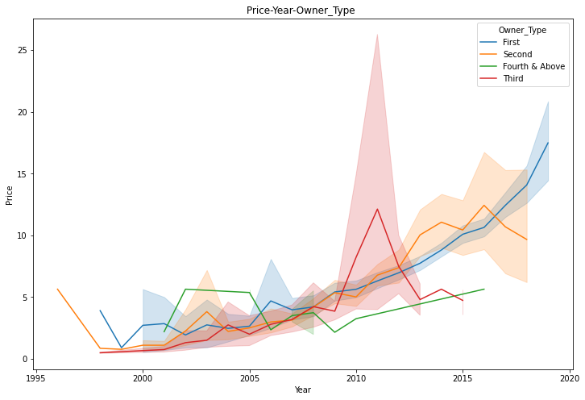

```python
#Price, Year, and Owner Type
plt.figure(figsize = (12,8))
sns.lineplot(x = 'Year', y = 'Price', hue = 'Owner_Type', ci = 95, data = df);
plt.title('Price-Year-Owner_Type ');
```

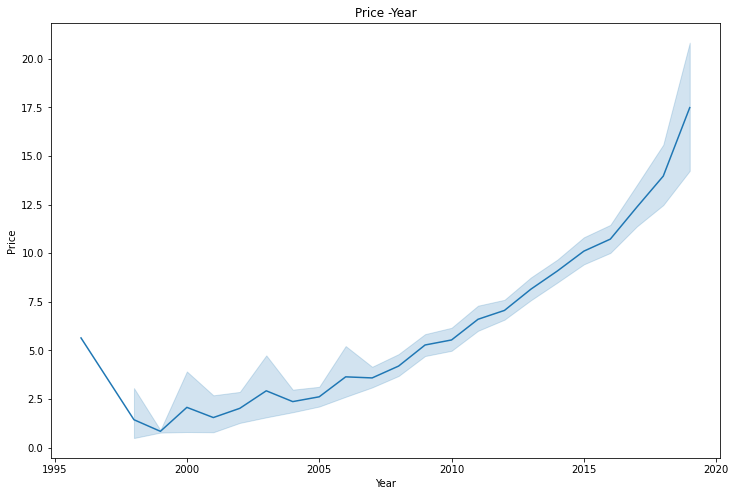

```python
#Price, Price-Year.
plt.figure(figsize = (12,8))
sns.lineplot(x = 'Year', y = 'Price', ci = 95, data = df);
plt.title('Price -Year');
```

### Plotting varaibles with multicollinearity

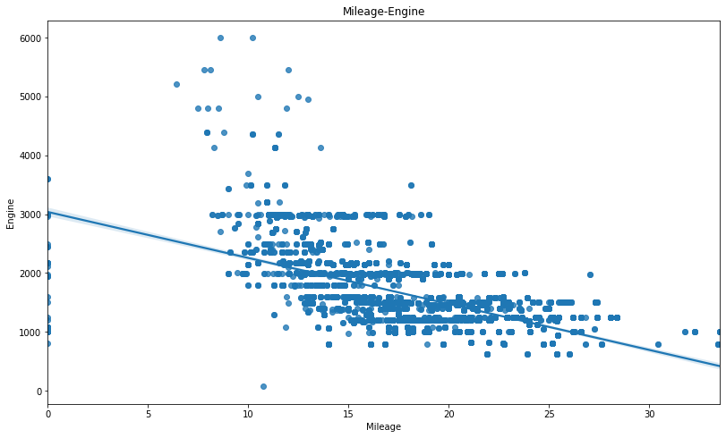

```python
# Engine and Mileage -Engine
plt.figure(figsize=[35,30])
ax0 = plt.subplot(grid[0,0])
sns.regplot(x= 'km_per_unit_fuel', y = 'engine_number',  data = df)
ax0.set_xlabel('Mileage')
ax0.set_ylabel('Engine')
plt.title('Mileage-Engine');
```

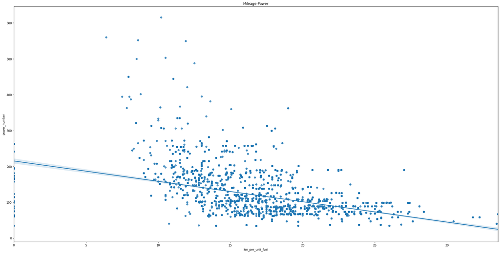

```python
# Power-number and  Mileage- Power
plt.figure(figsize=[30,15])
sns.regplot(x= 'km_per_unit_fuel', y = 'power_number', data = df)
plt.title('Mileage-Power');
```

```python
# Check Power-Engine
plt.figure(figsize=[20,15])
sns.regplot(x= 'power', y = 'engine_num', data = df)
ax2.set_xlabel('Power')
ax2.set_ylabel('Engine')
plt.title('Power-Engine')
plt.show();
```

[output not shown]

### Price - Seats

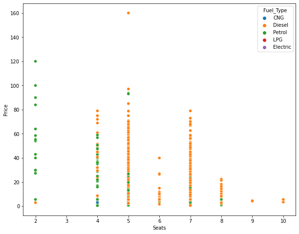

```python
plt.figure(figsize = (10,8))
sns.scatterplot(y = 'Price', x = 'Seats',hue = 'Fuel_Type' ,data = df);
```

Diesel cars has 5,6,7,8,9,10 and more seater than other fuel types car. But petrol cars usually has 2 seaters cars.

```python
df.info()
```

[output not shown]

### Data pre-processing-Data Preparation for modelling - Missing value Treatment - Outlier Treatment - Feature Engineering -10

## Data Preparation

### Fix data type

```python
#Exchanging object type column to category type
df['Location '] = df['Location'].astype('category')
df['Fuel_Type'] = df['Fuel_Type'].astype('category')
df['Transmission'] = df['Transmission'].astype('category')
df['Model'] = df['Model'].astype('category')
```

### Outliers Treatment

```python
# Treat outliers by capping and flooring.
def treat_outliers(df,col):
    '''
    treats outliers in a varaible
    col: str, name of the numerical varaible
    df: data frame
    col: name of the column
    '''
    Q1=df[col].quantile(0.25) # 25th quantile
    Q3=df[col].quantile(0.75)  # 75th quantile
    IQR=Q3-Q1
    Lower_Whisker = Q1 - 1.5*IQR
    Upper_Whisker = Q3 + 1.5*IQR
    df[col] = np.clip(df[col], Lower_Whisker, Upper_Whisker) # all the values samller than Lower_Whisker will be designated value of Lower_whisker
                                                            # and all the values bigger upper_whishker will be designated value of upper_Whisker
    return df

def treat_outliers_all(df, col_list):
    '''
    treat outlier in all numerical varaibles
    col_list: list of numerical varaibles
    df: data frame
    '''
    for c in col_list:
        df = treat_outliers(df,c)

    return df
```

### Treating the outiers

```python
numerical_col = df.select_dtypes(include=np.number).columns.tolist()
df = treat_outliers_all(df,numerical_col)
```

```python
# Check the box plot if outliers has been treated or not
plt.figure(figsize=(20,30))

for i, variable in enumerate(numeric_columns):
                     plt.subplot(5,4,i+1)
                     plt.boxplot(df[variable],whis=1.5)
                     plt.tight_layout()
                     plt.title(variable)

plt.show()
```

[output not shown]

### Transforming numerical columns

```python
#Transforming the columns
df['Kilometers_Driven_log'] = np.log(df['Kilometers_Driven'])

df['Price_log'] = np.log(df['Price'])
```

```python
print('Skewness check for Kilometers Driven')
print(df['Kilometers_Driven'].skew())
print(df['Kilometers_Driven_log'].skew())
print('-'*30)


print('Skewness check for Price')
print(df['Price'].skew())
print(df['Price_log'].skew())
print('-'*30)
```

[output not shown]

```python
#Drop the initial columns
df.drop(['Kilometers_Driven'], axis =1, inplace =True)
df.columns
```

```
Index(['Location', 'Year', 'Fuel_Type', 'Transmission', 'Owner_Type', 'Seats',
       'Price', 'km_per_unit_fuel', 'engine_number', 'power_number',
       'new_price_num', 'Model', 'Region', 'Kilometers_Driven_log',
       'Price_log'],
      dtype='object')
```

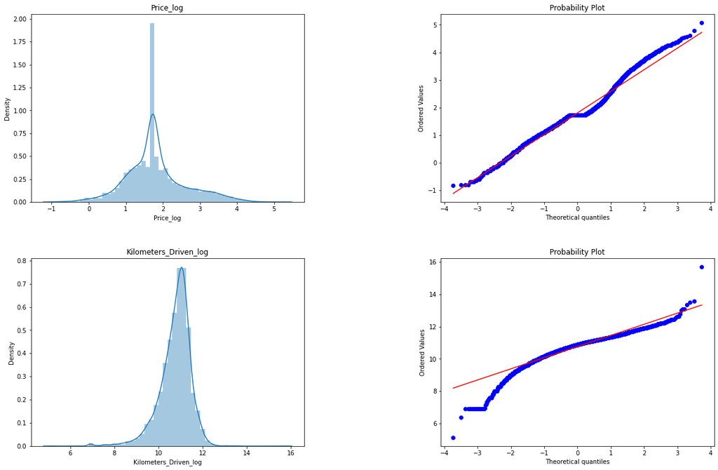

```python
#Transformation of  columns
#set pandas to display more rows

from scipy.stats import norm
import scipy.stats as stats
pd.set_option('display.max_rows', 200)


fig = plt.figure(figsize=[20,35]);
grid = plt.GridSpec(5, 2, wspace=0.5, hspace=0.3);
x = ['Price_log', 'Kilometers_Driven_log'];

#loop to populate boxplots within subplots
for i, a in enumerate(x):
    exec(f'ax{i}0 = plt.subplot(grid[i,0]);')
    exec(f'sns.distplot(df[a], ax=ax{i}0);')
    exec(f'ax{i}0.set_title(a);')
    exec(f'ax{i}1 = plt.subplot(grid[i,1]);')
    exec(f'stats.probplot(df[a],dist="norm",plot=pylab);')

fig.show();
```

#### Observations:

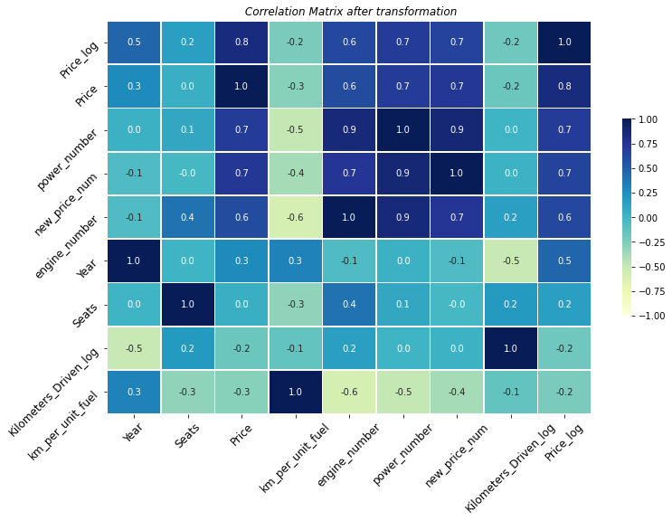

```python
numeric_columns = df.select_dtypes(include = np.number).columns.tolist()

#arranging correlations w.r.t Price
corr = df[numeric_columns].corr().sort_values(by = ['Price_log'], ascending = False)

# Matplotlib figure
f, ax = plt.subplots(figsize = (12,8))



# Heatmap with the mask and correct aspect ratio
sns.heatmap(corr, cmap = 'YlGnBu', annot = True, fmt = ".1f", vmin = -1, vmax = 1, center = 0, square = False,
            linewidths = .7, cbar_kws = {"shrink": .5});

plt.title(' Correlation Matrix after transformation', fontstyle = 'italic')
plt.tick_params(axis='both', labelsize = 12, labelrotation = 45)
plt.show()
```

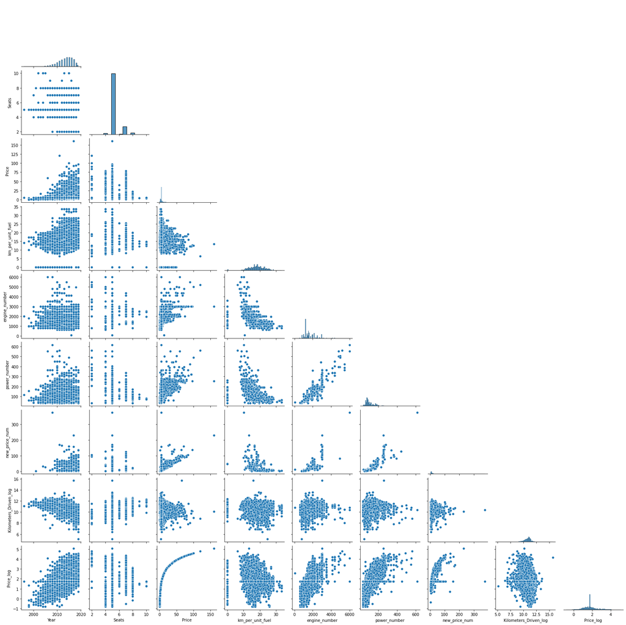

```python
sns.pairplot(df, corner=True);
```

Year is correlated with Price

### Create Dummy Variables

Some values like Mumbai or Pune cannot be read into an equivalence. Using alternatives like 2 for Pune, and 1 for Mumbai, so on would result in inferring several baseless statements which should be escaped. But Owner Type can be given substitutes such as 1 for First owner, 2 for Second Owner.

For the rest of the categorical variables dummy variables are creates and drop first =True is set. If we do not drop one of the dummies, then they become linearly related and violate model assumptions.

```python
df.head()
```

|  | Location | Year | Fuel_Type | Transmission | Owner_Type | Seats | Price | km_per_unit_fuel | engine_number | power_number | new_price_num | Model | Region | Kilometers_Driven_log | Price_log |
| --- | --- | --- | --- | --- | --- | --- | --- | --- | --- | --- | --- | --- | --- | --- | --- |
| 0 | Mumbai | 2010 | CNG | Manual | First | 5.000 | 1.750 | 26.600 | 998.000 | 58.160 | NaN | wagon | West_India | 11.184 | 0.560 |
| 1 | Pune | 2015 | Diesel | Manual | First | 5.000 | 12.500 | 19.670 | 1582.000 | 126.200 | NaN | creta | West_India | 10.621 | 2.526 |
| 2 | Chennai | 2011 | Petrol | Manual | First | 5.000 | 4.500 | 18.200 | 1199.000 | 88.700 | 8.610 | jazz | South_India | 10.736 | 1.504 |
| 3 | Chennai | 2012 | Diesel | Manual | First | 7.000 | 6.000 | 20.770 | 1248.000 | 88.760 | NaN | ertiga | South_India | 11.374 | 1.792 |
| 4 | Coimbatore | 2013 | Diesel | Automatic | Second | 5.000 | 17.740 | 15.200 | 1968.000 | 140.800 | NaN | a4 | South_India | 10.613 | 2.876 |

```python
df1 = df.copy()

ind_vars = df1.drop(["Price_log", 'Price'], axis=1)
dep_var = df1[["Price_log"]]
```

```python
def encode_cat_vars(x):
    x = pd.get_dummies(
        x,
        columns=x.select_dtypes(include=["object", "category"]).columns.tolist(),
        drop_first=True,
    )
    return x


ind_vars_num = encode_cat_vars(ind_vars)
ind_vars_num.head()
```

|  | Year | Seats | km_per_unit_fuel | engine_number | power_number | new_price_num | Kilometers_Driven_log | Location_Bangalore | Location_Chennai | Location_Coimbatore | Location_Delhi | Location_Hyderabad | Location_Jaipur | Location_Kochi | Location_Kolkata | Location_Mumbai | Location_Pune | Fuel_Type_Diesel | Fuel_Type_Electric | Fuel_Type_LPG | Fuel_Type_Petrol | Transmission_Manual | Owner_Type_Fourth & Above | Owner_Type_Second | Owner_Type_Third | Model_1.4gsi | Model_1000 | Model_3 | Model_370z | … |
| --- | --- | --- | --- | --- | --- | --- | --- | --- | --- | --- | --- | --- | --- | --- | --- | --- | --- | --- | --- | --- | --- | --- | --- | --- | --- | --- | --- | --- | --- | --- |
| 0 | 2010 | 5.000 | 26.600 | 998.000 | 58.160 | NaN | 11.184 | 0 | 0 | 0 | 0 | 0 | 0 | 0 | 0 | 1 | 0 | 0 | 0 | 0 | 0 | 1 | 0 | 0 | 0 | 0 | 0 | 0 | 0 | … |
| 1 | 2015 | 5.000 | 19.670 | 1582.000 | 126.200 | NaN | 10.621 | 0 | 0 | 0 | 0 | 0 | 0 | 0 | 0 | 0 | 1 | 1 | 0 | 0 | 0 | 1 | 0 | 0 | 0 | 0 | 0 | 0 | 0 | … |
| 2 | 2011 | 5.000 | 18.200 | 1199.000 | 88.700 | 8.610 | 10.736 | 0 | 1 | 0 | 0 | 0 | 0 | 0 | 0 | 0 | 0 | 0 | 0 | 0 | 1 | 1 | 0 | 0 | 0 | 0 | 0 | 0 | 0 | … |
| 3 | 2012 | 7.000 | 20.770 | 1248.000 | 88.760 | NaN | 11.374 | 0 | 1 | 0 | 0 | 0 | 0 | 0 | 0 | 0 | 0 | 1 | 0 | 0 | 0 | 1 | 0 | 0 | 0 | 0 | 0 | 0 | 0 | … |
| 4 | 2013 | 5.000 | 15.200 | 1968.000 | 140.800 | NaN | 10.613 | 0 | 0 | 1 | 0 | 0 | 0 | 0 | 0 | 0 | 0 | 1 | 0 | 0 | 0 | 0 | 0 | 1 | 0 | 0 | 0 | 0 | 0 | … |

## Model Building

```python
#split the data into train and test
from sklearn.model_selection import train_test_split
from sklearn.metrics import mean_absolute_error, mean_squared_error, r2_score
x_train, x_test, y_train, y_test = train_test_split(ind_vars_num, dep_var, test_size=0.3, random_state=1)
```

```python
#Size of the training and testing set
print('The size of the training and testing sets are: \n')
print('X train size', x_train.size)
print('-'*30)
print('X test size', x_test.size)
print('-'*30)
print('y train size', y_train.size)
print('-'*30)
print('y test size', y_test.size)

# Shape of the training and testing set
print('The shape of the training and testing sets are: \n')
print('X train size', x_train.shape)
print('-'*30)
print('X test size', x_test.shape)
print('-'*30)
print('y train size', y_train.shape)
print('-'*30)
print('y test size', y_test.shape)
```

```
The size of the training and testing sets are:

X train size 1243865
------------------------------
X test size 533120
------------------------------
y train size 5077
------------------------------
y test size 2176
The shape of the training and testing sets are:

X train size (5077, 245)
------------------------------
X test size (2176, 245)
------------------------------
y train size (5077, 1)
------------------------------
y test size (2176, 1)
```

## Choose Model, Train and Evaluate

```python
# Statsmodel api does not add a constant by default. We need to add it explicitly.

x_train = sm.add_constant(x_train)
# Add constant to test data
x_test = sm.add_constant(x_test)

def build_ols_model(train):
    # Create the model
    olsmodel = sm.ols(y_train["Price_log"], train)
    return olsmodel.fit()

   olsmodel1 = build_ols_model(x_train)

print(olsmodel1.summary())
```

[output not shown]

```python
import math

# RMSE
def rmse(predictions, targets):
    return np.sqrt(((targets - predictions) ** 2).mean())


# MAE
def mae(predictions, targets):
    return np.mean(np.abs((targets - predictions)))


# Model Performance on train and test data
def model_pref(olsmodel, x_train, x_test):

    # Insample Prediction
    y_pred_train_pricelog = olsmodel.predict(x_train)
    y_pred_train_Price = y_pred_train_pricelog.apply(math.exp)
    y_train_Price = y_train["Price_log"]

    # Prediction on test data
    y_pred_test_pricelog = olsmodel.predict(x_test)
    y_pred_test_Price = y_pred_test_pricelog.apply(math.exp)
    y_test_Price = y_test["Price_log"]

    print(
        pd.DataFrame(
            {
                "Data": ["Train", "Test"],
                "RMSE": [
                    rmse(y_pred_train_Price, y_train_Price),
                    rmse(y_pred_test_Price, y_test_Price),
                ],
                "MAE": [
                    mae(y_pred_train_Price, y_train_Price),
                    mae(y_pred_test_Price, y_test_Price),
                ],


            }
        )
    )


#Check model performance
model_pref(ols model1, x_train, x_test)
```

[output not shown]

### Checking the Linear Regression Assumptions

1.No Multicollinearity

2.Mean of residuals should be 0

3.No Heteroscedacity

4.Linearity of variables

5.Normality of error terms

### Check Multicollinearity using VIF scores

### TEST FOR MULTICOLLINEARITY

```python
from statsmodels.stats.outliers_influence import variance_inflation_factor


def checking_vif(train):
    vif = pd.DataFrame()
    vif["feature"] = train.columns

    # calculating VIF for each feature
    vif["VIF"] = [
        variance_inflation_factor(train.values, i) for i in range(len(train.columns))
    ]
    return vif


print(checking_vif(x_train))
```

[output not shown]

```python
#Will create a new column Car_Category by doing the following:_
df.groupby(["Model"])['new_price_num'].mean().sort_values(ascending=False)
```

```
Model
flying    375.000
s-class   171.000
7         154.667
cayenne   136.000
rs5       128.000
            ...
xenon         NaN
xj            NaN
yeti          NaN
z4            NaN
zen           NaN
Name: new_price_num, Length: 218, dtype: float64
```

```python
# We will have to create the x and y datasets again
y = df1[['Price_log']]
X = df1.drop(['Price_log', 'Price'], axis=1)


def encode_cat_vars(x):
    x = pd.get_dummies(
        x,
        columns=x.select_dtypes(include=["object", "category"]).columns.tolist(),
        drop_first=True,
    )
    return x


X = encode_cat_vars(X)
X.head()



# Splitting data into train and test
x_train, x_test, y_train, y_test = train_test_split(
    X, y, test_size=0.3, random_state=1)

print("Number of rows in train data =", x_train.shape[0])
print("Number of rows in train data =", x_test.shape[0], "\n\n")

# Statsmodel api does not add a constant by default. We need to add it explicitly.
x_train = sm.add_constant(x_train)
# Add constant to test data
x_test = sm.add_constant(x_test)

# Fit linear model on new dataset
olsmodel2 = build_ols_model(x_train)
print(olsmodel2.summary())
```

```
Number of rows in train data = 5077
Number of rows in train data = 2176
```

[output not shown]

```python
# Check VIF
print(checking_vif(x_train))
```

```python
# Checking model performance
model_pref(olsmodel2, x_train, x_test)  # No Overfitting.
```

### Removing Multicollinearity

```python
def treating_multicollinearity(high_vif_columns, x_train, x_test):
    """
    Drop every column that has VIF score greater than 5, one by one.
    Look at the adjusted R square of all these models
    Look at the RMSE of all these models on test data
    """
    adj_rsq_scores = []
    rmse_test_data = []

    # build ols models with dropping one of these at a time and observe the Adjusted R-squared
    for cols in high_vif_columns:
        train = x_train.loc[:, ~x_train.columns.str.startswith(cols)]
        test = x_test.loc[:, ~x_test.columns.str.startswith(cols)]
        # Create the model
        olsres = build_ols_model(train)
        # Adj R-Sq
        adj_rsq_scores.append(olsres.rsquared_adj)
        # RMSE (Test data)
        y_pred_test_pricelog = olsres.predict(test)
        y_pred_test_Price = y_pred_test_pricelog.apply(math.exp)
        y_test_Price = y_test["Price_log"]
        rmse_test_data.append(rmse(y_pred_test_Price, y_test_Price))

    # Add new Adj_Rsq and RMSE after dropping each colmn
    temp = pd.DataFrame(
        {
            "col": high_vif_columns,
            "Adj_rsq_after_dropping_col": adj_rsq_scores,
            "Test RMSE": rmse_test_data,
        }
    ).sort_values(by="Adj_rsq_after_dropping_col", ascending=False)

    print(temp)
    print("\n\n")
```

```python
high_vif_columns = [
    "engine_num",
    "power_num",
    "new_price_num_log",
    "Fuel_Type",
    "car_category",
]
treating_multicollinearity(high_vif_columns, x_train, x_test)
```

```python
# Fit linear model on new dataset
olsmodel3 = build_ols_model(x_train)
print(olsmodel3.summary())

print("\n\n")

# Check model performance
model_pref(olsmodel3, x_train, x_test)
```

[output not shown]

### Checking Assumption 2: Mean of residuals should be 0

```python
# Fit linear model on new dataset
olsmodel3 = build_ols_model(x_train)
print(olsmodel3.summary())

print("\n\n")

# Check model performance
model_pref(olsmodel3, x_train, x_test)
```

##### Checking Assumption 2: Mean of residuals should be 0

```python
pd.set_option('display.float_format', lambda x: '%.3f' % x)

residuals = olsmodel3.resid
np.mean(residuals)
```

### Checking Assumption 3: Linearity of variables

```python
# predicted values
fitted = olsmodel3.fittedvalues

# sns.set_style("whitegrid")
sns.residplot(fitted, residuals, color="purple", lowess=True)
plt.xlabel("Fitted Values")
plt.ylabel("Residual")
plt.title("Residual PLOT")
plt.show()
```

[output not shown]

### Checking Assumption 4: No Heteroscedasticity

#### TEST FOR HOMOSCEDASTICITY

```python
import statsmodels.stats.api as sms
from statsmodels.compat import lzip

name = ["F statistic", "p-value"]
test = sms.het_goldfeldquandt(residuals, x_train)
lzip(name, test)
```

### Checking Assumption 5: Normality of error terms

```python
# Check histogram of residuals
sns.distplot(residuals);
```

[output not shown]

## Plot q-q plot of residuals

```python
import pylab
import scipy.stats as stats

stats.probplot(residuals, dist="norm", plot=pylab)
plt.show()
```

[output not shown]

```python
print(olsmodel3.summary())
```

### Observations from the model

### Observation

The model indicates that the most significant predictors of price of used cars are -

The year of manufacturing

Number of seats in the car

Power of the engine

Mileage

Kilometers Driven

Location

Fuel_Type

Transmission - Automatic/Manual

Mileage is inversely correlated with Price. Generally, high Mileage cars are the lower budget cars. It is important to note here that correlation is not equal to causation. That is to say that increase in Mileage does not lead to a drop in prices. It can be understood in such a way that the cars with high mileage do not have a high power engine and therefore have low prices.

Kilometers Driven have a negative relationship with the price which is intuitive. A car that has been driven more will have more wear and tear and hence sell at a lower price, everything else being 0.

## Add-on: Analyzing predictions where we were way off the mark

```python
# Removing the rows from original data frame df where indexes are same as the training data
original_df = df[df.index.isin(x_train.index.values)].copy()

# Removing predicted values from the final model
residuals = olsmodel3.resid
fitted_values = olsmodel3.fittedvalues

# Add new columns for predicted values
original_df["Predicted price_log "] = fitted_values
original_df["Predicted Price"] = fitted_values.apply(math.exp)
original_df["residuals"] = residuals
original_df["Abs_residuals"] = residuals.apply(math.exp)
original_df["Difference in Lakhs"] = np.abs(
    original_df["Price"] - original_df["Predicted Price"]
)

# Check 20 predictions in where our model made highest extimation errors (on train data)
original_df.sort_values(by=["Difference in Lakhs"], ascending=False).head(10)
```

```python
sns.scatterplot(
    original_df["Difference Lakhs"],
    original_df["Price"],
    hue=original_df["Fuel_Type"],
);
```

[output not shown]

```python
pip install spacy
```

### Recommendation

1.Year is positive correlated with Price: So New car is more valuable. 2.Price and Kilometers has negative correlation: So, Les milage cars are more valuable. 3.Manual cars price has shown a smooth incline over the time: So manual car is less valuable.

4.Petrol and Diesel used cars price show a continual increase. But Diesel cars are more expensive than Petrol cars. So, prefer diesel cars over petrol cars. 5.The price for electric cars is constant across the years: Soon electric cars is more valuable.